# Comparative analysis of single cell transcriptomes of human blastoids

JD

2021-02-03

- BioProject Accession: PRJNA632846
- GEO Accession: GSE150570

Load required packages.

```r
library(tidyverse)
library(magrittr)
library(Matrix)
library(patchwork)
library(extrafont)
```

```r
Sys.time()
```

```
## [1] "2021-02-03 22:00:52 CST"
```

# Data preparation

## Functions loading

```r
source(
    file = file.path(
        SCRIPT_DIR,
        "utilities.R"
    )
)

load_matrix <- function(x) {
    matrix_readcount_use <- scipy.sparse$load_npz(
        file.path(x, "matrix_readcount.npz")
    )

    colnames(matrix_readcount_use) <- np$load(
        file.path(x, "matrix_readcount_barcodes.npy")
    )

    rownames(matrix_readcount_use) <- np$load(
        file.path(x, "matrix_readcount_features.npy")
    )

    return(matrix_readcount_use)
}
```

```r
perform_pca <- function(matrix, features, min_counts = 1) {
    matrix_norm <- matrix[
        Matrix::rowSums(
            matrix
        ) >= min_counts,
    ]

    matrix_norm <- as(matrix_norm, "dgCMatrix")
    matrix_norm@x <- median(colSums(matrix_norm)) *
        (matrix_norm@x / rep.int(
            colSums(matrix_norm),
            diff(matrix_norm@p)
        ))

    matrix_norm_log <- matrix_norm[
        rownames(matrix_norm) %in% features,
    ]
    matrix_norm_log@x <- log1p(matrix_norm_log@x)

    # z-score
    matrix_norm_log_scaled <- t(
        scale(
            t(
                matrix_norm_log
            ),
            center = TRUE, scale = TRUE
        )
    )

    # PCA
    pca_out <- prcomp(
        t(matrix_norm_log_scaled),
        center = FALSE,
        scale = FALSE
    )

    return(pca_out)
}
```

## Data loading

```r
PROJECT_DIR <- "/Users/jialei/Dropbox/Data/Projects/UTSW/Human_blastoid"
```

### Matrix

```r
np <- reticulate::import("numpy", convert = TRUE)
scipy.sparse <- reticulate::import(module = "scipy.sparse", convert = TRUE)
```

```r
matrix_dir <- list(
    "github/data/matrices/LW36",
    "github/data/matrices/LW49_LW50_LW51_LW52",
    "github/data/matrices/LW58_LW59",
    "github/data/matrices/LW60_LW61",
    "raw/public/PRJEB11202/reformatted_matrix"
)

matrix_readcount_use <- purrr::map(matrix_dir, function(x) {
    load_matrix(file.path(PROJECT_DIR, x))
}) %>%
    purrr::reduce(cbind)

walk(list(matrix_readcount_use), function(x) {
    print(object.size(x), units = "auto", standard = "SI")
})
```

```
## 1.6 GB
```

### Embedding

```r
EMBEDDING_FILE <- "embedding.csv.gz"

embedding <- read_csv(
    file = file.path(
        PROJECT_DIR,
        "github",
        "data",
        EMBEDDING_FILE
    )
)
rm(EMBEDDING_FILE)
```

### Metadata

```r
cell_metadata_PRJEB11202 <- read_delim(
    file.path(
        PROJECT_DIR,
        "raw/public/PRJEB11202/",
        "E-MTAB-3929.sdrf.tsv"
    ),
    delim = "\t"
) %>%
    dplyr::select(
        `Comment[ENA_SAMPLE]`,
        `Comment[ENA_RUN]`,
        `Characteristics[developmental stage]`,
        `Characteristics[inferred lineage]`
    ) %>%
    dplyr::rename(
        cell = `Comment[ENA_SAMPLE]`,
        run = `Comment[ENA_RUN]`,
        developmental_stage = `Characteristics[developmental stage]`,
        lineage = `Characteristics[inferred lineage]`
    ) %>%
    mutate(
        developmental_stage = str_replace(
            string = developmental_stage,
            pattern = "embryonic day ",
            replacement = "E"
        ),
        lineage = case_when(
            lineage == "epiblast" ~ "EPI",
            lineage == "primitive endoderm" ~ "HYP",
            lineage == "trophectoderm" ~ "TE",
            lineage == "not applicable" ~ "Pre-lineage"
        )
    )

embedding %<>%
    left_join(
        cell_metadata_PRJEB11202
    ) %>%
    mutate(
        lineage = case_when(
            is.na(lineage) ~ "Blastoid",
            TRUE ~ as.character(lineage)
        ),
        developmental_stage = case_when(
            is.na(developmental_stage) ~ "Blastoid",
            TRUE ~ as.character(developmental_stage)
        )
    )

# matrix_readcount_use <- matrix_readcount_use[, embedding$cell]
# matrix_cpm_use <- calc_cpm(matrix_readcount_use)

walk(list(matrix_readcount_use), function(x) {
    print(object.size(x), units = "auto", standard = "SI")
})
```

```
## 1.6 GB
```

### Blastoid

```r
matrix_readcount_blastoid_meta <- purrr::map(
    sort(unique(embedding$louvain)), function(x) {
        cells_in_group <- embedding %>%
            filter(
                louvain == x,
                batch != "PRJEB11202"
            ) %>%
            pull(cell)

        rowSums(matrix_readcount_use[, cells_in_group])
    }
) %>%
    purrr::reduce(cbind) %>%
    `colnames<-`(sort(unique(embedding$louvain)))
```

### Derived cell lines

```r
EMBEDDING_FILE <- "embedding_stem.csv.gz"

embedding_stem <- read_csv(
    file = file.path(
        PROJECT_DIR,
        "github",
        "data",
        EMBEDDING_FILE
    )
)
```

```r
matrix_readcount_stem_meta <- purrr::map(
    sort(unique(embedding_stem$batch)), function(x) {
        cells_in_group <- embedding_stem %>%
            filter(batch == x) %>%
            pull(cell)

        rowSums(matrix_readcount_use[, cells_in_group])
    }
) %>%
    purrr::reduce(cbind) %>%
    `colnames<-`(sort(unique(embedding_stem$batch)))
```

### Features

```r
features_hg_cy <- read_csv(
    file = file.path(
        PROJECT_DIR,
        "github",
        "data",
        "features_hg_cy.csv.gz"
    )
)
# prepare features
table_s3_sheet1 <- readxl::read_excel(
    path = file.path(
        PROJECT_DIR,
        "docs",
        "Reconstituting_the_transcriptome_and_DNA_methylome_landscapes_of_human_implantation/41586_2019_1500_MOESM3_ESM",
        "Supplementary Table 3 Lineage_Markers.xlsx"
    ),
    sheet = "Sheet1"
)
table_s3_sheet1
```

| gene | myAUC | avg_diff | power | pct.1 | pct.2 | cluster |
| --- | --- | --- | --- | --- | --- | --- |
| DPPA5 | 0.987 | 4.287821 | 0.974 | 0.985 | 0.247 | EPI |
| IFITM1 | 0.987 | 3.334142 | 0.974 | 0.997 | 0.593 | EPI |
| POU5F1 | 0.986 | 3.814455 | 0.972 | 0.988 | 0.355 | EPI |
| KHDC3L | 0.970 | 4.646703 | 0.940 | 0.958 | 0.123 | EPI |
| TDGF1 | 0.970 | 3.947136 | 0.940 | 0.958 | 0.202 | EPI |
| ESRG | 0.964 | 3.447912 | 0.928 | 0.961 | 0.393 | EPI |
| DPPA4 | 0.962 | 2.613504 | 0.924 | 0.967 | 0.677 | EPI |
| SCGB3A2 | 0.958 | 3.883492 | 0.916 | 0.939 | 0.156 | EPI |
| MEG3 | 0.957 | 3.252234 | 0.914 | 0.955 | 0.174 | EPI |
| IFITM3 | 0.957 | 1.951206 | 0.914 | 0.997 | 0.835 | EPI |

[output cut: 951 more lines]

```r
features_hg_EPI <- rownames(matrix_readcount_use)[
    str_remove(
        rownames(matrix_readcount_use),
        "^E.+_"
    ) %in% (table_s3_sheet1 %>%
        filter(
            cluster == "EPI"
        ) %>%
        pull(gene))
] %>%
    unique()

features_hg_cy_EPI_hg <- features_hg_cy %>%
    filter(hg %in% features_hg_EPI) %>%
    pull(hg)

features_hg_cy_EPI_cy <- features_hg_cy %>%
    filter(hg %in% features_hg_EPI) %>%
    pull(cy)

# count number
map_int(list(features_hg_cy_EPI_hg, features_hg_cy_EPI_cy), length)
```

```
## [1] 303 303
```

```r
features_hg_TE <- rownames(matrix_readcount_use)[
    str_remove(
        rownames(matrix_readcount_use),
        "^E.+_"
    ) %in% (table_s3_sheet1 %>%
        filter(
            cluster == "TE"
        ) %>%
        pull(gene))
] %>%
    unique()

features_hg_cy_TE_hg <- features_hg_cy %>%
    filter(hg %in% features_hg_TE) %>%
    pull(hg)

features_hg_cy_TE_cy <- features_hg_cy %>%
    filter(hg %in% features_hg_TE) %>%
    pull(cy)

# count number
map_int(list(features_hg_cy_TE_hg, features_hg_cy_TE_cy), length)
```

```
## [1] 87 87
```

```r
features_hg_HYP <- rownames(matrix_readcount_use)[
    str_remove(
        rownames(matrix_readcount_use),
        "^E.+_"
    ) %in% (table_s3_sheet1 %>%
        filter(
            cluster == "PE"
        ) %>%
        pull(gene))
] %>%
    unique()

features_hg_cy_HYP_hg <- features_hg_cy %>%
    filter(hg %in% features_hg_HYP) %>%
    pull(hg)

features_hg_cy_HYP_cy <- features_hg_cy %>%
    filter(hg %in% features_hg_HYP) %>%
    pull(cy)

purrr::map_int(list(features_hg_cy_HYP_hg, features_hg_cy_HYP_cy), length)
```

```
## [1] 242 242
```

# Pre/post-implantation comparison

## Data loading

### PRJEB11202

[Single-Cell RNA-Seq Reveals Lineage and X Chromosome Dynamics in Human Preimplantation Embryos](https://doi.org/10.1016/j.cell.2016.03.023)

Notebook: https://github.com/jlduan/Replica/tree/master/j.cell.2016.03.023

```r
matrix_readcount_PRJEB11202_meta_lineage <- purrr::map(
    c(
        "Pre-lineage",
        "EPI",
        "HYP",
        "TE"
    ), function(x) {
        cells_in_group <- embedding %>%
            filter(
                lineage == x,
                batch == "PRJEB11202"
            ) %>%
            pull(cell)

        Matrix::rowSums(matrix_readcount_use[, cells_in_group])
    }
) %>%
    purrr::reduce(cbind) %>%
    `colnames<-`(c(
        "Pre-lineage",
        "EPI",
        "HYP",
        "TE"
    )) %>%
    as.matrix()

matrix_readcount_PRJEB11202_meta_EPI <- purrr::map(
    c("E5", "E6", "E7"), function(x) {
        cells_in_group <- embedding %>%
            filter(
                lineage == "EPI",
                developmental_stage == x
            ) %>%
            pull(cell)

        Matrix::rowSums(matrix_readcount_use[, cells_in_group])
    }
) %>%
    purrr::reduce(cbind) %>%
    `colnames<-`(c("E5", "E6", "E7")) %>%
    as.matrix()

matrix_readcount_PRJEB11202_meta_TE <- purrr::map(
    c("E5", "E6", "E7"), function(x) {
        cells_in_group <- embedding %>%
            filter(
                lineage == "TE",
                developmental_stage == x
            ) %>%
            pull(cell)

        Matrix::rowSums(matrix_readcount_use[, cells_in_group])
    }
) %>%
    purrr::reduce(cbind) %>%
    `colnames<-`(c("E5", "E6", "E7")) %>%
    as.matrix()

matrix_readcount_PRJEB11202_meta_HYP <- purrr::map(
    c("E5", "E6", "E7"), function(x) {
        cells_in_group <- embedding %>%
            filter(
                lineage == "HYP",
                developmental_stage == x
            ) %>%
            pull(cell)

        Matrix::rowSums(matrix_readcount_use[, cells_in_group])
    }
) %>%
    purrr::reduce(cbind) %>%
    `colnames<-`(c("E5", "E6", "E7")) %>%
    as.matrix()
```

### PRJNA562548

[A developmental landscape of 3D-cultured human pre-gastrulation embryos](https://doi.org/10.1038/s41586-019-1875-y)

- BioProject Accession: PRJNA562548
- GEO Accession: GSE136447

Notebook: https://github.com/jlduan/Replica/tree/master/s41586-019-1875-y

```r
matrix_readcount_PRJNA562548 <- load_matrix(
    file.path(PROJECT_DIR, "raw/public/PRJNA562548/reformatted_matrix")
)

embedding_PRJNA562548 <- read_csv(
    file = file.path(
        PROJECT_DIR,
        "raw/public/PRJNA562548/notebooks/embedding_ncomponents31_seed20200317.csv"
    )
) %>%
    dplyr::rename(Run = cell) %>%
    left_join(
        read_csv(
            file = file.path(
                PROJECT_DIR,
                "raw/public/PRJNA562548/SraRunTable.txt"
            )
        ) %>%
            dplyr::select(Run, Age, Cell_type, `Sample Name`),
    ) %>%
    rename(
        developmental_stage = Age,
        lineage = Cell_type,
        run = Run,
        cell = `Sample Name`
    ) %>%
    dplyr::relocate(
        cell, everything()
    ) %>%
    mutate(
        louvain = factor(louvain),
        #
        developmental_stage = str_replace(
            string = developmental_stage,
            pattern = "embryo invitro day ",
            replacement = "E"
        ),
        developmental_stage = factor(
            developmental_stage,
            levels = stringr::str_sort(
                x = unique(developmental_stage),
                numeric = TRUE
            )
        ),
        lineage = factor(
            lineage,
            levels = c(
                "ICM",
                "EPI",
                "PSA-EPI",
                "Hypoblast",
                "CTBs",
                "STBs",
                "EVTs"
            )
        )
    )
```

```r
matrix_readcount_PRJNA562548_meta_EPI <- purrr::map(
    levels(embedding_PRJNA562548$developmental_stage), function(x) {
        cells_in_group <- embedding_PRJNA562548 %>%
            filter(
                lineage == "EPI",
                developmental_stage == x
            ) %>%
            pull(cell)

        rowSums(matrix_readcount_PRJNA562548[, cells_in_group])
    }
) %>%
    purrr::reduce(cbind) %>%
    `colnames<-`(levels(embedding_PRJNA562548$developmental_stage)) %>%
    as.matrix()

matrix_readcount_PRJNA562548_meta_HYP <- purrr::map(
    levels(embedding_PRJNA562548$developmental_stage), function(x) {
        cells_in_group <- embedding_PRJNA562548 %>%
            filter(
                lineage == "Hypoblast",
                developmental_stage == x
            ) %>%
            pull(cell)

        if (length(cells_in_group) > 1) {
            m <- Matrix::rowSums(matrix_readcount_PRJNA562548[, cells_in_group])
        } else {
            m <- matrix_readcount_PRJNA562548[, cells_in_group]
        }

        return(m)
    }
) %>%
    purrr::reduce(cbind) %>%
    `colnames<-`(
        embedding_PRJNA562548 %>%
            filter(lineage == "Hypoblast") %>%
            pull(developmental_stage) %>%
            droplevels() %>%
            levels()
    ) %>%
    as.matrix()

# clean up
rm(matrix_readcount_PRJNA562548)
rm(embedding_PRJNA562548)
```

### PRJNA431392

[Reconstituting the transcriptome and DNA methylome landscapes of human implantation](https://doi.org/10.1038/s41586-019-1500-0)

- BioProject Accession: PRJNA431392
- GEO Accession: GSE109555

Notebook: https://github.com/jlduan/Replica/tree/master/s41586-019-1500-0

```r
matrix_readcount_PRJNA431392 <- load_matrix(
    file.path(PROJECT_DIR, "raw/public/PRJNA431392")
)

embedding_PRJNA431392 <- read_csv(
    file = file.path(
        PROJECT_DIR,
        "raw/public/PRJNA431392/notebooks/embedding_ncomponents8_seed20200317.csv"
    )
) %>%
    left_join(
        read_csv(
            file = file.path(
                PROJECT_DIR,
                "raw/public/PRJNA431392/Supplementary_Table_2_Sample_Information.csv"
            )
        ) %>%
            select(
                Sample,
                Day,
                IVC,
                Embryo,
                Ori_Day,
                Ori_Day_Emb,
                Sex,
                CNV,
                Lineage
            ) %>%
            rename_all(tolower),
        by = c("cell" = "sample")
    ) %>%
    mutate(
        developmental_stage = str_replace(
            string = day,
            pattern = "D",
            replacement = "E"
        ),
        developmental_stage = factor(
            developmental_stage,
            levels = c(str_sort(unique(developmental_stage), numeric = TRUE))
        ),
        #
        lineage = ifelse(lineage == "MIX", "ysTE", lineage),
        lineage = factor(lineage, levels = c("EPI", "PE", "TE", "ysTE"))
    )
```

```r
matrix_readcount_PRJNA431392_meta_EPI <- purrr::map(
    levels(embedding_PRJNA431392$developmental_stage), function(x) {
        cells_in_group <- embedding_PRJNA431392 %>%
            filter(
                developmental_stage == x,
                lineage == "EPI"
            ) %>%
            pull(cell)

        rowSums(matrix_readcount_PRJNA431392[, cells_in_group])
    }
) %>%
    purrr::reduce(cbind) %>%
    `colnames<-`(levels(embedding_PRJNA431392$developmental_stage)) %>%
    as.matrix()

matrix_readcount_PRJNA431392_meta_TE <- purrr::map(
    levels(embedding_PRJNA431392$developmental_stage), function(x) {
        cells_in_group <- embedding_PRJNA431392 %>%
            filter(
                developmental_stage == x,
                lineage == "TE"
            ) %>%
            pull(cell)

        rowSums(matrix_readcount_PRJNA431392[, cells_in_group])
    }
) %>%
    purrr::reduce(cbind) %>%
    `colnames<-`(levels(embedding_PRJNA431392$developmental_stage)) %>%
    as.matrix()

matrix_readcount_PRJNA431392_meta_HYP <- purrr::map(
    levels(embedding_PRJNA431392$developmental_stage), function(x) {
        cells_in_group <- embedding_PRJNA431392 %>%
            filter(
                developmental_stage == x,
                lineage == "PE"
            ) %>%
            pull(cell)

        rowSums(matrix_readcount_PRJNA431392[, cells_in_group])
    }
) %>%
    purrr::reduce(cbind) %>%
    `colnames<-`(levels(embedding_PRJNA431392$developmental_stage)) %>%
    as.matrix()

# clean up
rm(matrix_readcount_PRJNA431392)
rm(embedding_PRJNA431392)
```

### PRJEB7132

[Resetting Transcription Factor Control Circuitry toward Ground-State Pluripotency in Human](https://doi.org/10.1016/j.cell.2014.08.029)

- BioProject Accession: PRJEB7132
- ArrayExpress Accession: E-MTAB-2857

Notebook: https://github.com/jlduan/Replica/tree/master/j.cell.2014.08.029

```r
matrix_readcount_PRJEB7132 <- load_matrix(
    file.path(PROJECT_DIR, "raw/public/PRJEB7132")
)

matrix_readcount_PRJEB7132_meta <- cbind(
    H9 = Matrix::rowSums(
        matrix_readcount_PRJEB7132[, c("ERS537888", "ERS537890", "ERS537878")]
    ),
    H9_reset = Matrix::rowSums(
        matrix_readcount_PRJEB7132[, c("ERS537884", "ERS537881", "ERS537876")]
    )
) %>%
    as.matrix()

# clean up
rm(matrix_readcount_PRJEB7132)
```

### PRJNA576801

[Derivation of trophoblast stem cells from naïve human pluripotent stem cells](https://doi.org/10.7554/eLife.52504)

- BioProject Accession: PRJNA576801
- GEO Accession: GSE138688

Notebook: https://github.com/jlduan/Replica/tree/master/eLife.52504

```r
matrix_readcount_PRJNA576801 <- load_matrix(
    file.path(PROJECT_DIR, "raw/public/PRJNA576801")
)

geo_info_PRJNA576801 <- tibble::tribble(
    ~sample_name,                ~sample_annotation,         ~sample_annotation2, ~cell_line,
    # "GSM4116149",      "H9 primed TSC Bulk RNA-seq", "Primed hPSC (hTSC medium)",       "H9",
    # "GSM4116150",      "AN primed TSC Bulk RNA-seq", "Primed hPSC (hTSC medium)",       "AN",
    "GSM4116151",          "H9 primed Bulk RNA-seq",               "Primed hPSC",       "H9",
    "GSM4116152",          "AN primed Bulk RNA-seq",               "Primed hPSC",       "AN",
    # "GSM4116153",  "H9 primed StemPro Bulk RNA-seq",            "Re-primed hPSC",       "H9",
    # "GSM4116154",   "H9 capacitated 1 Bulk RNA-seq",          "Capacitated hPSC",       "H9",
    # "GSM4116155",   "H9 capacitated 2 Bulk RNA-seq",          "Capacitated hPSC",       "H9",
    "GSM4116156",           "H9 naïve Bulk RNA-seq",                "Naïve hPSC",       "H9",
    "GSM4116157",           "AN naïve Bulk RNA-seq",                "Naïve hPSC",       "AN",
    "GSM4116158",       "H9 naïve TSC Bulk RNA-seq",                "Naïve hTSC",       "H9",
    "GSM4116159",       "AN naïve TSC Bulk RNA-seq",                "Naïve hTSC",       "AN",
    "GSM4116160",    "WIBR3 naïve TSC Bulk RNA-seq",                "Naïve hTSC",    "WIBR3",
    # "GSM4116161",             "H9 EVT Bulk RNA-seq",                       "EVT",       "H9",
    # "GSM4116162",             "AN EVT Bulk RNA-seq",                       "EVT",       "AN",
    # "GSM4116163",             "H9 STB Bulk RNA-seq",                       "STB",       "H9",
    # "GSM4116164",             "AN STB Bulk RNA-seq",                       "STB",       "AN",
    "GSM4276363", "H9 naïve TSC rep 2 Bulk RNA-seq",                "Naïve hTSC",       "H9",
    "GSM4276364", "AN naïve TSC rep 2 Bulk RNA-seq",                "Naïve hTSC",       "AN",
    # "GSM4276365",     "BT5 hTSC rep 1 Bulk RNA-seq",                 "BT5 hTSCs",      "BT5",
    # "GSM4276366",     "BT5 hTSC rep 2 Bulk RNA-seq",                 "BT5 hTSCs",      "BT5"
)


cell_metadata_PRJNA576801 <- read_delim(
    file = file.path(
        PROJECT_DIR,
        "raw/public/PRJNA576801",
        "SraRunTable.txt"
    ),
    delim = ","
) %>%
    rename_all(. %>% tolower()) %>%
    `colnames<-`(str_replace(
        string = colnames(.),
        pattern = " ", replacement = "_"
    )) %>%
    select(
        sample_name,
        run,
        biosample,
        source_name
    ) %>%
    mutate(
        source_name = str_remove(string = source_name, pattern = "\\s.+$"),
        source_name = factor(
            source_name,
            levels = c("hPSC", "hTSC", "EVT", "STB"),
        )
    ) %>%
    left_join(geo_info_PRJNA576801) %>%
    mutate(cell_line = factor(cell_line)) %>%
    tidyr::drop_na() %>%
    mutate(
        sample_annotation2 = factor(sample_annotation2)
    )
```

```r
matrix_readcount_PRJNA576801_meta_lineage <- purrr::map(
    levels(cell_metadata_PRJNA576801$sample_annotation2), function(x) {
        cells_in_group <- cell_metadata_PRJNA576801 %>%
            filter(
                sample_annotation2 == x
            ) %>%
            pull(sample_name)

        rowSums(matrix_readcount_PRJNA576801[, cells_in_group])
    }
) %>%
    purrr::reduce(cbind) %>%
    `colnames<-`(levels(cell_metadata_PRJNA576801$sample_annotation2)) %>%
    as.matrix()

colnames(matrix_readcount_PRJNA576801_meta_lineage) %<>% str_replace(
    pattern = " ", replacement = "_"
)

rm(matrix_readcount_PRJNA576801)
rm(geo_info_PRJNA576801)
rm(cell_metadata_PRJNA576801)
```

### PRJNA638350

[Naïve Human Embryonic Stem Cells Can Give Rise to Cells with a Trophoblast-like Transcriptome and Methylome](https://doi.org/10.1016/j.stemcr.2020.06.003)

- BioProject Accession: PRJNA638350
- GEO Accession: GSE152101

Notebook: https://github.com/jlduan/Replica/tree/master/j.stemcr.2020.06.003

```r
matrix_readcount_PRJNA638350 <- load_matrix(
    file.path(PROJECT_DIR, "raw/public/PRJNA638350")
)

geo_info_PRJNA638350 <- tibble::tribble(
    ~sample_name, ~sample_description, ~source_name2, ~source_name3, ~cell_line,
    "GSM4603117", "BT2 hTSC Rep1", "BT2 hTSC", "hTSC", "BT2",
    "GSM4603118", "BT2 hTSC Rep2", "BT2 hTSC", "hTSC", "BT2",
    "GSM4603119", "BT2 hTSC Rep3", "BT2 hTSC", "hTSC", "BT2",
    "GSM4603120", "BT2 hTSC Rep4", "BT2 hTSC", "hTSC", "BT2",
    "GSM4603121", "CT1 hTSCs Rep1", "CT1 hTSC", "hTSC", "CT1",
    "GSM4603122", "CT1 hTSCs Rep2", "CT1 hTSC", "hTSC", "CT1",
    "GSM4603123", "CT1 hTSCs Rep3", "CT1 hTSC", "hTSC", "CT1",
    "GSM4603124", "CT1 hTSCs Rep4", "CT1 hTSC", "hTSC", "CT1",
    "GSM4603125", "CT1 hTSCs Rep5", "CT1 hTSC", "hTSC", "CT1",
    "GSM4603126", "CT1 hTSCs Rep6", "CT1 hTSC", "hTSC", "CT1",
    "GSM4603127", "CT1 hTSCs Rep7", "CT1 hTSC", "hTSC", "CT1",
    "GSM4603128", "CT3 hTSCs Rep1", "CT3 hTSC", "hTSC", "CT3",
    "GSM4603129", "CT3 hTSCs Rep2", "CT3 hTSC", "hTSC", "CT3",
    "GSM4603130", "CT3 hTSCs Rep3", "CT3 hTSC", "hTSC", "CT3",
    "GSM4603131", "CT3 hTSCs Rep4", "CT3 hTSC", "hTSC", "CT3",
    # "GSM4603132",   "UCLA1 Primed hESCs Rep1", "UCLA1 Primed hESC", "Primed hESC",    "UCLA1",
    # "GSM4603133",   "UCLA1 Primed hESCs Rep2", "UCLA1 Primed hESC", "Primed hESC",    "UCLA1",
    # "GSM4603134",   "UCLA1 Primed hESCs Rep3", "UCLA1 Primed hESC", "Primed hESC",    "UCLA1",
    "GSM4603135", "WIBR3 Primed hESCs Rep 1", "WIBR3 Primed hESC", "Primed hESC", "WIBR3",
    "GSM4603136", "WIBR3 Primed hESCs Rep 2", "WIBR3 Primed hESC", "Primed hESC", "WIBR3",
    "GSM4603137", "WIBR3 Primed hESCs Rep 3", "WIBR3 Primed hESC", "Primed hESC", "WIBR3",
    "GSM4603138", "WIBR3 Primed hESCs Rep 4", "WIBR3 Primed hESC", "Primed hESC", "WIBR3",
    # "GSM4603139",   "WIBR3 Naive hESCs Rep 1",  "WIBR3 Naive hESC", "Primed hESC",    "WIBR3",
    # "GSM4603140",   "WIBR3 Naive hESCs Rep 2",  "WIBR3 Naive hESC", "Primed hESC",    "WIBR3",
    "GSM4603139", "WIBR3 Naive hESCs Rep 1", "WIBR3 Naive hESC", "Naive hESC", "WIBR3",
    "GSM4603140", "WIBR3 Naive hESCs Rep 2", "WIBR3 Naive hESC", "Naive hESC", "WIBR3",
    "GSM4603141", "WIBR3 tdhTSC Line 1 Rep 1", "WIBR3 tdhTSC", "tdhTSC", "WIBR3",
    "GSM4603142", "WIBR3 tdhTSC Line 1 Rep 2", "WIBR3 tdhTSC", "tdhTSC", "WIBR3",
    "GSM4603143", "WIBR3 tdhTSC Line 2 Rep1", "WIBR3 tdhTSC", "tdhTSC", "WIBR3",
    "GSM4603144", "WIBR3 tdhTSC Line 2 Rep 2", "WIBR3 tdhTSC", "tdhTSC", "WIBR3",
    "GSM4603145", "WIBR3 tdhTSC Line 3 Rep 1", "WIBR3 tdhTSC", "tdhTSC", "WIBR3",
    "GSM4603146", "UCLA1 tdhTSC Line 1 Rep 1", "UCLA1 tdhTSC", "tdhTSC", "UCLA1",
    "GSM4603147", "UCLA1 tdhTSC Line 1 Rep 2", "UCLA1 tdhTSC", "tdhTSC", "UCLA1",
    "GSM4603148", "FT190", "FT190", "FT190", "FT190",
    "GSM4603149", "Hec116", "Hec116", "Hec116", "Hec116"
)

cell_metadata_PRJNA638350 <- read_delim(
    file = file.path(
        PROJECT_DIR,
        "raw/public/PRJNA638350",
        "SraRunTable.txt"
    ),
    delim = ","
) %>%
    rename_all(. %>% tolower()) %>%
    `colnames<-`(str_replace(
        string = colnames(.),
        pattern = " ", replacement = "_"
    )) %>%
    select(
        sample_name,
        run,
        biosample,
        source_name,
        cell_type
    ) %>%
    left_join(geo_info_PRJNA638350, by = "sample_name") %>%
    mutate(
        source_name3 = factor(
            source_name3,
            # levels = c("Primed hESC", "tdhTSC", "hTSC", "FT190", "Hec116")
            levels = c("Naive hESC", "Primed hESC", "tdhTSC", "hTSC", "FT190", "Hec116")
        ),
        source_name2 = factor(
            source_name2,
            levels = c(
                "WIBR3 Naive hESC",
                "WIBR3 Primed hESC",
                # "UCLA1 Primed hESC",
                "WIBR3 tdhTSC",
                "UCLA1 tdhTSC",
                "CT1 hTSC",
                "CT3 hTSC",
                "BT2 hTSC",
                "FT190",
                "Hec116"
            )
        )
    ) %>%
    tidyr::drop_na()
```

```r
matrix_readcount_PRJNA638350_meta_lineage <- purrr::map(
    levels(cell_metadata_PRJNA638350$source_name3), function(x) {
        cells_in_group <- cell_metadata_PRJNA638350 %>%
            filter(
                source_name3 == x
            ) %>%
            pull(sample_name)

        if (length(cells_in_group) > 1) {
            m <- rowSums(matrix_readcount_PRJNA638350[, cells_in_group])
        } else {
            m <- matrix_readcount_PRJNA638350[, cells_in_group]
        }
        return(m)
    }
) %>%
    purrr::reduce(cbind) %>%
    `colnames<-`(levels(cell_metadata_PRJNA638350$source_name3)) %>%
    as.matrix()

colnames(matrix_readcount_PRJNA638350_meta_lineage) %<>% str_replace(
    pattern = " ", replacement = "_"
)

# clean up
rm(matrix_readcount_PRJNA638350)
rm(cell_metadata_PRJNA638350)
```

### PRJNA516921

[Single-cell RNA sequencing reveals regulatory mechanism for trophoblast cell-fate divergence in human peri-implantation conceptuses(https://doi.org/10.1371/journal.pbio.3000187)

- BioProject Accession: PRJNA516921
- GEO Accession: GSE125616

Notebook: https://github.com/jlduan/Replica/tree/master/journal.pbio.3000187

```r
matrix_readcount_PRJNA516921 <- load_matrix(
    file.path(PROJECT_DIR, "raw/public/PRJNA516921")
)

geo_info_PRJNA516921 <- read_delim(
    file = file.path(
        PROJECT_DIR,
        "raw/public/PRJNA516921",
        "notebooks",
        "sample.csv"
    ),
    delim = ","
)
cell_metadata_PRJNA516921 <- read_delim(
    file = file.path(
        PROJECT_DIR,
        "raw/public/PRJNA516921",
        "SraRunTable.txt"
    ),
    delim = ","
) %>%
    rename_all(. %>% tolower()) %>%
    `colnames<-`(str_replace(
        string = colnames(.),
        pattern = " ", replacement = "_"
    )) %>%
    select(
        sample_name,
        run,
        biosample,
        development_day,
        source_name,
        stage
    ) %>%
    left_join(
        geo_info_PRJNA516921 %>%
            select(Accession, Title),
        by = c("sample_name" = "Accession")
    ) %>%
    rename_all(. %>% tolower()) %>%
    dplyr::rename(
        developmental_stage = "development_day",
    ) %>%
    mutate(
        developmental_stage = str_replace(
            string = developmental_stage,
            pattern = "day",
            replacement = "Day "
        ),
        developmental_stage = factor(
            developmental_stage,
            levels = developmental_stage %>%
                unique() %>%
                str_sort(numeric = TRUE)
        ),
        stage = str_to_title(string = stage),
        stage = factor(
            stage,
            levels = c(
                "Blastocyst", "Implantation", "Post-Implantation", "Endometrial"
            )
        )
    )
embedding_PRJNA516921 <- read_csv(
    file = file.path(
        PROJECT_DIR,
        "raw/public/PRJNA516921",
        "exploring/embedding_ncomponents14_seed20200317.csv"
    )
) %>%
    left_join(
        cell_metadata_PRJNA516921,
        by = c("cell" = "sample_name")
    ) %>%
    select(
        cell:y_umap, run:last_col()
    ) %>%
    filter(
        !(
            louvain == 3 | (
                developmental_stage == "Day 6" & louvain == 1
            ) | (
                developmental_stage %in% c("Day 13", "Day 14")
            )
        )
    ) %>%
    mutate(
        lineage = case_when(
            cell %in% c(
                "GSM3578305",
                "GSM3578308",
                "GSM3578339",
                "GSM3578505",
                "GSM3578651",
                "GSM3578653",
                "GSM3578682",
                "GSM3578696",
                "GSM3578697",
                "GSM3578707",
                "GSM3578729"
            ) ~ "PE",
            cell %in% c(
                "GSM3578300",
                "GSM3578302",
                "GSM3578365",
                "GSM3578492",
                "GSM3578515",
                "GSM3578666",
                "GSM3578668",
                "GSM3578714",
                "GSM3578716",
                "GSM3578728"
            ) ~ "EPI",
            TRUE ~ "TE"
        ),
        lineage = factor(
            lineage,
            levels = c("EPI", "PE", "TE")
        )
    )
```

```r
matrix_readcount_PRJNA516921_meta_TE <- purrr::map(
    levels(embedding_PRJNA516921$developmental_stage), function(x) {
        cells_in_group <- embedding_PRJNA516921 %>%
            filter(
                lineage == "TE",
                developmental_stage == x
            ) %>%
            pull(cell)

        if (length(cells_in_group) > 1) {
            m <- rowSums(matrix_readcount_PRJNA516921[, cells_in_group])
        } else {
            m <- matrix_readcount_PRJNA516921[, cells_in_group]
        }
        return(m)
    }
) %>%
    purrr::reduce(cbind) %>%
    `colnames<-`(embedding_PRJNA516921 %>%
        filter(lineage == "TE") %>%
        pull(developmental_stage) %>%
        droplevels() %>%
        levels()) %>%
    as.matrix()

rm(matrix_readcount_PRJNA516921)
rm(geo_info_PRJNA516921)
rm(cell_metadata_PRJNA516921)
```

### PRJNA574150

[Naïve human pluripotent stem cells respond to Wnt, Nodal and LIF signalling to produce expandable naïve extra-embryonic endoderm](https://doi.org/10.1242/dev.180620)

- BioProject Accession: PRJNA574150
- GEO Accession: GSE138012

Notebook: https://github.com/jlduan/Replica/tree/master/dev.180620

```r
matrix_readcount_PRJNA574150 <- load_matrix(
    file.path(PROJECT_DIR, "raw/public/PRJNA574150")
)

geo_info_PRJNA574150 <- tibble::tribble(
    ~sample_name, ~sample_description,
    "GSM4096610",         "H9_pES_R1",
    "GSM4096611",         "H9_pES_R2",
    "GSM4096612",  "H9_t2iLGo_nES_R2",
    "GSM4096613",  "H9_t2iLGo_nES_R1",
    "GSM4096614",  "H9_t2iLGo_nES_R3",
    "GSM4096615",    "H9_h2iL_nES_R1",
    "GSM4096616",    "H9_h2iL_nES_R2",
    "GSM4096617",    "H9_h2iL_nES_R3",
    "GSM4096618",  "H9_t2iLGo_PrE_R2",
    "GSM4096619",  "H9_t2iLGo_PrE_R3",
    "GSM4096620",  "H9_t2iLGo_PrE_R1",
    "GSM4096621",    "H9_h2iL_PrE_R2",
    "GSM4096622",    "H9_h2iL_PrE_R3",
    "GSM4096623",    "H9_h2iL_PrE_R1",
    "GSM4096624",      "HUES4_pES_R1",
    "GSM4096625",      "HUES4_pES_R2",
    "GSM4096626",         "H9_ADE_R1",
    "GSM4096627",         "H9_ADE_R2",
    "GSM4096628",      "HUES4_ADE_R2",
    "GSM4096629",      "HUES4_ADE_R1",
    "GSM4096630",    "H9_RSeT_nES_R1",
    "GSM4096631",    "H9_RSeT_nES_R2",
    "GSM4096632", "H9_t2iLGo_nEnd_R1",
    "GSM4096633", "H9_t2iLGo_nEnd_R2",
    "GSM4096634", "H9_t2iLGo_nEnd_R3",
    "GSM4096635",  "H9_RSeT_PrE_R1-1",
    "GSM4096636",  "H9_RSeT_PrE_R2-1",
    "GSM4096637",          "H9_DE_R1",
    "GSM4096638",          "H9_DE_R2",
    "GSM4096639",          "H9_DE_R3",
    "GSM4096640",  "H9_RSeT_PrE_R1-2",
    "GSM4096641",  "H9_RSeT_PrE_R2-2",
    "GSM4096642",   "H9_RSeT_nEnd_R1",
    "GSM4096643",   "H9_RSeT_nEnd_R2",
    "GSM4096644",   "H9_RSeT_nEnd_R3"
)

cell_metadata_PRJNA574150 <- read_delim(
    file = file.path(
        PROJECT_DIR,
        "raw/public/PRJNA574150",
        "SraRunTable.txt"
    ),
    delim = ","
) %>%
    rename_all(. %>% tolower()) %>%
    `colnames<-`(str_replace(
        string = colnames(.),
        pattern = " ", replacement = "_"
    )) %>%
    select(
        sample_name,
        run,
        biosample,
        cell_type,
        background,
        source_name,
        stage
    ) %>%
    left_join(geo_info_PRJNA574150, by = "sample_name") %>%
    mutate(
        sample_description2 = str_remove(
            string = sample_description,
            pattern = "_R\\d.*$"
        ),
        lineage = str_remove(
            string = sample_description2, pattern = ".+_"
        ),
        lineage = factor(
            lineage,
            levels = c("nES", "pES", "PrE", "nEnd", "DE", "ADE")
        )
    ) %>%
    dplyr::rename(cell_line = "background")
```

```r
matrix_readcount_PRJNA574150_meta_lineage <- purrr::map(
    levels(cell_metadata_PRJNA574150$lineage), function(x) {
        cells_in_group <- cell_metadata_PRJNA574150 %>%
            filter(
                lineage == x,
            ) %>%
            pull(sample_name)

        if (length(cells_in_group) > 1) {
            m <- rowSums(matrix_readcount_PRJNA574150[, cells_in_group])
        } else {
            m <- matrix_readcount_PRJNA574150[, cells_in_group]
        }
        return(m)
    }
) %>%
    purrr::reduce(cbind) %>%
    `colnames<-`(levels(cell_metadata_PRJNA574150$lineage)) %>%
    as.matrix()

rm(matrix_readcount_PRJNA574150)
rm(geo_info_PRJNA574150)
rm(cell_metadata_PRJNA574150)
```

## PCA

### EPI

```r
# z-score
clusters_selected_blastoid <- c("2", "3", "11")

matrix_readcount_pca <- cbind(
    matrix_readcount_blastoid_meta[, clusters_selected_blastoid],
    #
    matrix_readcount_stem_meta[, c("LW50"), drop = FALSE],
    #
    matrix_readcount_PRJEB11202_meta_EPI,
    matrix_readcount_PRJNA562548_meta_EPI,
    matrix_readcount_PRJNA431392_meta_EPI,
    matrix_readcount_PRJEB7132_meta,
    matrix_readcount_PRJNA576801_meta_lineage[, c("Naïve_hPSC", "Primed_hPSC")],
    matrix_readcount_PRJNA638350_meta_lineage[, c("Naive_hESC", "Primed_hESC")]
)

# name columns
colnames(matrix_readcount_pca) <- paste(
    rep(
        c(
            "Blastoid",
            #
            "Blastoid",
            #
            "PRJEB11202",
            "PRJNA562548",
            "PRJNA431392",
            "PRJEB7132",
            "PRJNA576801",
            "PRJNA638350"
        ),
        times = c(
            length(clusters_selected_blastoid),
            #
            ncol(matrix_readcount_stem_meta[, c("LW50"), drop = FALSE]),
            #
            ncol(matrix_readcount_PRJEB11202_meta_EPI),
            ncol(matrix_readcount_PRJNA562548_meta_EPI),
            ncol(matrix_readcount_PRJNA431392_meta_EPI),
            ncol(matrix_readcount_PRJEB7132_meta),
            length(c("Naïve_hPSC", "Primed_hPSC")),
            length(c("Naive_hESC", "Primed_hESC"))
        )
    ),
    colnames(matrix_readcount_pca),
    sep = ":"
)
```

```r
pca_out_EPI <- perform_pca(
    matrix = matrix_readcount_pca,
    features = features_hg_cy_EPI_hg,
    min_counts = 1
)

embedding_pca_EPI <- pca_out_EPI$x %>%
    as.data.frame() %>%
    rownames_to_column(var = "sample_name") %>%
    select(sample_name:PC3) %>%
    dplyr::rename(
        x_pca = PC1,
        y_pca = PC2,
        z_pca = PC3
    ) %>%
    relocate(x_pca, y_pca, z_pca, .after = last_col()) %>%
    mutate(
        lineage = str_remove(string = sample_name, pattern = "^P.+:"),
        dataset = str_remove(string = sample_name, pattern = ":.+$")
    )
```

### TE

```r
clusters_selected_blastoid <- c("0", "1", "8", "9", "12", "17")

matrix_readcount_pca <- cbind(
    matrix_readcount_blastoid_meta[, clusters_selected_blastoid],
    #
    matrix_readcount_stem_meta[, c("LW52"), drop = FALSE],
    #
    matrix_readcount_PRJEB11202_meta_TE,
    matrix_readcount_PRJNA431392_meta_TE,
    #
    matrix_readcount_PRJNA576801_meta_lineage,
    matrix_readcount_PRJNA638350_meta_lineage[, c("Naive_hESC", "Primed_hESC", "tdhTSC", "hTSC")],
    matrix_readcount_PRJNA516921_meta_TE
)

# name columns
colnames(matrix_readcount_pca) <- paste(
    rep(
        c(
            "Blastoid",
            #
            "Blastoid",
            #
            "PRJEB11202",
            "PRJNA431392",
            #
            "PRJNA576801",
            "PRJNA638350",
            "PRJNA516921"
        ),
        times = c(
            ncol(matrix_readcount_blastoid_meta[, clusters_selected_blastoid]),
            #
            ncol(matrix_readcount_stem_meta[, c("LW52"), drop = FALSE]),
            #
            ncol(matrix_readcount_PRJEB11202_meta_TE),
            ncol(matrix_readcount_PRJNA431392_meta_TE),
            #
            ncol(matrix_readcount_PRJNA576801_meta_lineage),
            length(c("Naive_hESC", "Primed_hESC", "tdhTSC", "hTSC")),
            ncol(matrix_readcount_PRJNA516921_meta_TE)
        )
    ),
    colnames(matrix_readcount_pca),
    sep = ":"
)

colnames(matrix_readcount_pca) <- str_replace_all(
    string = colnames(matrix_readcount_pca),
    pattern = " ",
    replacement = "_"
)

matrix_readcount_pca <- matrix_readcount_pca[
    , colnames(matrix_readcount_pca) %in% c(
        "Blastoid:0",
        "Blastoid:1",
        "Blastoid:8",
        "Blastoid:9",
        "Blastoid:12",
        "Blastoid:17",
        "Blastoid:LW52",
        "PRJEB11202:E5",
        "PRJEB11202:E6",
        "PRJEB11202:E7",
        "PRJNA431392:E6",
        "PRJNA431392:E8",
        "PRJNA431392:E10",
        "PRJNA431392:E12",
        "PRJNA576801:Naïve_hTSC",
        "PRJNA638350:tdhTSC",
        "PRJNA638350:hTSC",
        "PRJNA516921:Day_6",
        "PRJNA516921:Day_7",
        "PRJNA516921:Day_8",
        "PRJNA516921:Day_9",
        "PRJNA516921:Day_10"
    )
]
```

```r
pca_out_TE <- perform_pca(
    matrix = matrix_readcount_pca,
    features = features_hg_cy_TE_hg,
    min_counts = 1
)

embedding_pca_TE <- pca_out_TE$x %>%
    as.data.frame() %>%
    rownames_to_column(var = "sample_name") %>%
    select(sample_name:PC3) %>%
    dplyr::rename(
        x_pca = PC1,
        y_pca = PC2,
        z_pca = PC3
    ) %>%
    relocate(x_pca, y_pca, z_pca, .after = last_col()) %>%
    mutate(
        lineage = str_remove(string = sample_name, pattern = "^P.+:"),
        dataset = str_remove(string = sample_name, pattern = ":.+$")
    )
```

### HYP

```r
clusters_selected_blastoid <- c("18", "15", "16", "13")

matrix_readcount_pca <- cbind(
    matrix_readcount_blastoid_meta[, clusters_selected_blastoid, drop = FALSE],
    #
    matrix_readcount_stem_meta[, c("LW51"), drop = FALSE],
    #
    matrix_readcount_PRJEB11202_meta_HYP,
    matrix_readcount_PRJNA562548_meta_HYP,
    matrix_readcount_PRJNA431392_meta_HYP,
    #
    matrix_readcount_PRJNA574150_meta_lineage[, "nEnd", drop = FALSE]
)

# name columns
colnames(matrix_readcount_pca) <- paste(
    rep(
        c(
            "Blastoid",
            #
            "Blastoid",
            #
            "PRJEB11202",
            "PRJNA562548",
            "PRJNA431392",
            #
            "PRJNA574150"
        ),
        times = c(
            length(clusters_selected_blastoid),
            #
            ncol(matrix_readcount_stem_meta[, c("LW51"), drop = FALSE]),
            #
            ncol(matrix_readcount_PRJEB11202_meta_HYP),
            ncol(matrix_readcount_PRJNA562548_meta_HYP),
            ncol(matrix_readcount_PRJNA431392_meta_HYP),
            #
            length("nEnd")
        )
    ),
    colnames(matrix_readcount_pca),
    sep = ":"
)

colnames(matrix_readcount_pca) <- str_replace_all(
    string = colnames(matrix_readcount_pca),
    pattern = " ",
    replacement = "_"
)
```

```r
pca_out_HYP <- perform_pca(
    matrix = matrix_readcount_pca,
    features = features_hg_cy_HYP_hg,
    min_counts = 1
)

embedding_pca_HYP <- pca_out_HYP$x %>%
    as.data.frame() %>%
    rownames_to_column(var = "sample_name") %>%
    select(sample_name:PC3) %>%
    dplyr::rename(
        x_pca = PC1,
        y_pca = PC2,
        z_pca = PC3
    ) %>%
    relocate(x_pca, y_pca, z_pca, .after = last_col()) %>%
    mutate(
        lineage = str_remove(string = sample_name, pattern = "^P.+:"),
        dataset = str_remove(string = sample_name, pattern = ":.+$")
    )
```

## Visualization, joint

```r
# assign colors

public_datasets <- tibble::tribble(
    ~bioproject, ~description,
    "Blastoid", "Blastoid",
    "PRJEB11202", "Petropoulos et al. 2016",
    "PRJEB7132", "Takashima et al. 2014",
    "PRJNA431392", "Zhou et al. 2019",
    "PRJNA516921", "lv et al. 2019",
    "PRJNA562548", "Xiang et al. 2020",
    "PRJNA574150", "Linneberg-Agerholm et al. 2019",
    "PRJNA576801", "Dong et al. 2020",
    "PRJNA638350", "Cinkornpumin et al. 2020"
) %>%
    mutate(color = c(
        "#F8766D",
        "#D39200",
        "#93AA00",
        "#00BA38",
        "#00C19F",
        "#00B9E3",
        "#619CFF",
        "#DB72FB",
        "#FF61C3"
    ))
```

```r
# prepare embeddings

embedding_pca_EPI %<>%
    mutate(
        dataset = factor(
            dataset,
            levels = public_datasets$bioproject
        )
    )

embedding_pca_HYP %<>%
    mutate(
        y_pca = 0 - y_pca,
        dataset = factor(
            dataset,
            levels = public_datasets$bioproject
        ),
    )

embedding_pca_TE %<>%
    mutate(
        dataset = factor(
            dataset,
            levels = public_datasets$bioproject
        ),
        #
        lineage = str_replace(string = lineage, pattern = "Day_", replacement = "E")
    )
```

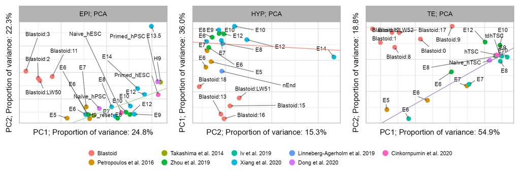

```r
p1 <- plot_pca_embedding(
    data = embedding_pca_EPI,
    x = x_pca,
    y = y_pca,
    color = dataset,
    title = "EPI; PCA",
    legend_x = 0.5,
    legend_y = 0.995,
    min_segment_length = 0
) + add_xy_label_pca(pca_out_EPI) +
    scale_color_manual(
        values = public_datasets$color,
        breaks = public_datasets$bioproject,
        labels = public_datasets$description,
        drop = FALSE
    ) +
    theme(legend.position = "bottom") +
    ggplot2::guides(colour = ggplot2::guide_legend(
        override.aes = list(size = 2.5), nrow = 2,
    ))
ab <- coef(MASS::rlm(y_pca ~ x_pca, data = embedding_pca_EPI %>% filter(dataset != "Blastoid")))
p1 <- p1 + geom_abline(intercept = ab[1], slope = ab[2], color = "#8ace7e", size = 0.2)

p2 <- plot_pca_embedding(
    data = embedding_pca_HYP,
    x = y_pca,
    y = x_pca,
    color = dataset,
    title = "HYP; PCA",
    legend_x = 0.5,
    legend_y = 0.995,
    min_segment_length = 0
) + add_xy_label_pca(pca_out_HYP, "PC2", "PC1") +
    scale_color_manual(
        values = public_datasets$color,
        breaks = public_datasets$bioproject,
        labels = public_datasets$description,
        drop = FALSE
    ) +
    theme(legend.position = "bottom") +
    ggplot2::guides(colour = ggplot2::guide_legend(
        override.aes = list(size = 2.5), nrow = 2
    ))
ab <- coef(MASS::rlm(x_pca ~ y_pca, data = embedding_pca_HYP %>% filter(dataset != "Blastoid")))
p2 <- p2 + geom_abline(intercept = ab[1], slope = ab[2], color = "#ff684c", size = 0.2)

p3 <- plot_pca_embedding(
    data = embedding_pca_TE,
    x = x_pca,
    y = y_pca,
    color = dataset,
    title = "TE; PCA",
    legend_x = 0.5,
    legend_y = 0.995,
    min_segment_length = 0
) + add_xy_label_pca(pca_out_TE) +
    scale_color_manual(
        values = public_datasets$color,
        breaks = public_datasets$bioproject,
        labels = public_datasets$description,
        drop = FALSE
    ) +
    theme(legend.position = "bottom") +
    ggplot2::guides(colour = ggplot2::guide_legend(
        override.aes = list(size = 2.5), nrow = 2
    ))
ab <- coef(MASS::rlm(y_pca ~ x_pca, data = embedding_pca_TE %>% filter(dataset != "Blastoid")))
p3 <- p3 + geom_abline(intercept = ab[1], slope = ab[2], color = "#9467bd", size = 0.2)

list(p1 + p2 + p3) %>%
    purrr::reduce(`+`) +
    patchwork::plot_layout(ncol = 3, guides = "collect") +
    patchwork::plot_annotation(theme = theme(plot.margin = margin())) &
    theme(legend.position = "bottom", legend.direction = "horizontal")
```

# Monkey comparison

[Single-cell transcriptome of early embryos and cultured embryonic stem cells of cynomolgus monkeys](https://doi.org/10.1038/nature19096)

- BioProject Accession: PRJNA301445
- GEO Accession: GSE74767

Notebook: https://github.com/jlduan/Replica/tree/master/nature19096

## Data loading

```r
color_palette_cluster <- c(
    "0" = "#8DD3C7",
    "1" = "#9EDAE5FF",
    "2" = "#BEBADA",
    "3" = "#FB8072",
    "4" = "#80B1D3",
    "5" = "#FDB462",
    "6" = "#B3DE69",
    "7" = "#FCCDE5",
    "8" = "#DC863B",
    "9" = "#BC80BD",
    "10" = "#11c638",
    "11" = "#BCBD22FF",
    "12" = "#17BECFFF",
    "13" = "#AEC7E8FF",
    "14" = "#EAD3C6",
    "15" = "#98DF8AFF",
    "16" = "#FF9896FF",
    "17" = "#C5B0D5FF",
    "18" = "#C49C94FF",
    "19" = "#F7B6D2FF",
    "20" = "#D33F6A",
    "21" = "#8E063B",
    "22" = "#023FA5"
)

# prepare matrix
matrix_cpm_PRJNA301445_cy <- load_matrix(
    file.path(PROJECT_DIR, "raw/public/PRJNA301445/preprocessed/cy")
)

embedding_PRJNA301445_cy <- read_csv(
    file = file.path(
        PROJECT_DIR,
        "raw/public/PRJNA301445/Comparison/cy_EPI/embedding_cy.csv"
    )
) %>%
    mutate(
        group = factor(
            group,
            levels = c(
                "ICM",
                "Pre-EPI",
                "Hypoblast",
                "PreE-TE",
                "PreL-TE",
                "PostE-EPI",
                "PostL-EPI",
                "Gast1",
                "Gast2a",
                "Gast2b",
                "Post-paTE",
                "VE/YE",
                "EXMC",
                "cyESCFF",
                "cyESCoF"
                # "E5.5EPI",
                # "E5.5VE",
                # "E6.5EPI-T hi",
                # "E6.5EPI-T lo",
                # "E6.5VE",
                # "EpiLC",
                # "2i+L ESC"
            )
        )
    )
```

```r
matrix_cpm_PRJNA301445_cy_meta_lineage <- purrr::map(
    levels(embedding_PRJNA301445_cy$group), function(x) {
        cells_in_group <- embedding_PRJNA301445_cy %>%
            filter(
                group == x
            ) %>%
            pull(cell)

        rowMeans(matrix_cpm_PRJNA301445_cy[, cells_in_group])
    }
) %>%
    purrr::reduce(cbind) %>%
    `colnames<-`(levels(embedding_PRJNA301445_cy$group)) %>%
    as.matrix()

rm(matrix_cpm_PRJNA301445_cy)
rm(embedding_PRJNA301445_cy)
```

```r
# prepare features
features_hg_cy_EPI_HYP_TE_hg <- features_hg_cy %>%
    filter(
        hg %in% (
            c(
                features_hg_cy_EPI_hg,
                features_hg_cy_HYP_hg,
                features_hg_cy_TE_hg
            ) %>% unique()
        )
    ) %>%
    pull(hg)

features_hg_cy_EPI_HYP_TE_cy <- features_hg_cy %>%
    filter(
        hg %in% (
            c(
                features_hg_cy_EPI_hg,
                features_hg_cy_HYP_hg,
                features_hg_cy_TE_hg
            ) %>% unique()
        )
    ) %>%
    pull(cy)
```

```r
matrix_corr <- cbind(
    calc_cpm(matrix_readcount_blastoid_meta)[features_hg_cy_EPI_HYP_TE_hg, ],
    matrix_cpm_PRJNA301445_cy_meta_lineage[features_hg_cy_EPI_HYP_TE_cy, ]
)

matrix_heatmap_corr_EPI_HYP_TE <- cor(log10(matrix_corr + 1) %>% as.matrix())
```

```r
matrix_heatmap_corr_EPI_HYP_TE <- matrix_heatmap_corr_EPI_HYP_TE[
    c("11", "18", "0", "1", "8", "9", "12", "17"),
    c(
        "ICM", "Pre-EPI", "PostE-EPI", "PostL-EPI", "Gast1", "Gast2a", "Gast2b",
        "Hypoblast", "PreE-TE", "PreL-TE", "Post-paTE"
    )
]
```

## Correlation heatmap

```r
colnames(matrix_heatmap_corr_EPI_HYP_TE) <- paste(
    rep(
        c("EPI", "HYP", "TE"),
        times = c(7, 1, 3)
    ),
    colnames(matrix_heatmap_corr_EPI_HYP_TE),
    sep = ":"
)

ha_group <- str_remove(
    string = colnames(matrix_heatmap_corr_EPI_HYP_TE),
    pattern = ":.+$"
)

ha_column <- ComplexHeatmap::HeatmapAnnotation(
    lineage = ComplexHeatmap::anno_simple(
        colnames(matrix_heatmap_corr_EPI_HYP_TE),
        # pch = anno_labels_cluster,
        col = setNames(
            # object = ggthemes::tableau_color_pal("Tableau 20")(ncol(matrix_heatmap_corr)),
            gg_color_hue(n = ncol(matrix_heatmap_corr_EPI_HYP_TE)),
            nm = colnames(matrix_heatmap_corr_EPI_HYP_TE)
        ),
        which = "column",
        pt_size = unit(2, "mm"),
        pt_gp = grid::gpar(
            fontfamily = "Arial",
            fontsize = 5
        ),
        simple_anno_size = unit(2, "mm")
    ),
    show_annotation_name = TRUE,
    annotation_label = c(
        "Lineage"
    ),
    annotation_name_gp = grid::gpar(fontfamily = "Arial", fontsize = 6),
    annotation_name_side = "left"
)
```

```r
ha_left <- ComplexHeatmap::HeatmapAnnotation(
    cluster = ComplexHeatmap::anno_simple(
        rownames(matrix_heatmap_corr_EPI_HYP_TE),
        col = color_palette_cluster,
        which = "row",
        # pt_size = unit(2, "mm"),
        pt_gp = grid::gpar(
            fontfamily = "Arial",
            fontsize = 5
        ),
        simple_anno_size = unit(2, "mm")
    ),
    #
    lineage = ComplexHeatmap::anno_simple(
        rownames(matrix_heatmap_corr_EPI_HYP_TE) %>%
            enframe() %>%
            mutate(
                color = case_when(
                    value %in% c(11) ~ "EPI",
                    value %in% c(18) ~ "HYP",
                    value %in% c(0, 1, 8, 9, 12, 17) ~ "TE",
                    value %in% c(10, 14) ~ "Pre-lineage",
                    TRUE ~ "Blastoid"
                )
            ) %>%
            pull(color),
        col = setNames(
            object = c("grey70", "#8ace7e", "#ff684c", "#9467bd", "#ffd8b1"),
            nm = c("Blastoid", "EPI", "HYP", "TE", "Pre-lineage")
        ),
        which = "row",
        # pt_size = unit(2, "mm"),
        pt_gp = grid::gpar(
            fontfamily = "Arial",
            fontsize = 5
        ),
        simple_anno_size = unit(2, "mm")
    ),
    # ,
    which = "row",
    show_annotation_name = FALSE,
    annotation_label = c(
        "Cluster",
        "Lineage"
    ),
    annotation_name_gp = grid::gpar(fontfamily = "Arial", fontsize = 6)
)
```

```r
colors_ <- as.character(
    wesanderson::wes_palette("Zissou1", 10, type = "continuous")
)

col_fun <- circlize::colorRamp2(
    seq(0, 0.6, 0.1),
    # viridis::plasma(11)
    # wesanderson::wes_palette("Zissou1", 51, type = "continuous")
    colors_[c(1, 2, 3, 5, 7, 9, 10)]
)

ht <- ComplexHeatmap::Heatmap(
    matrix_heatmap_corr_EPI_HYP_TE,
    # name = "heatmap",
    # col = wesanderson::wes_palette("Zissou1", 50, type = "continuous"),
    col = col_fun,
    border = NA,
    rect_gp = grid::gpar(col = "white", lwd = 1),
    cell_fun = function(j, i, x, y, width, height, fill) {
        # grid::grid.text(sprintf("%.2f", corr_heatmap[i, j]), x, y, gp = grid::gpar(fontsize = 6))
        grid::grid.text(
            round(matrix_heatmap_corr_EPI_HYP_TE[i, j], 2),
            x, y,
            gp = grid::gpar(fontsize = 5)
        )
    },
    #
    cluster_rows = FALSE,
    cluster_columns = FALSE,
    #
    # row_labels = str_remove(string = rownames(matrix_heatmap), pattern = "^E.+_"),
    row_names_side = c("left"),
    row_names_gp = grid::gpar(fontfamily = "Arial", fontsize = 6),
    show_row_names = TRUE,
    #
    column_labels = str_remove(string = colnames(matrix_heatmap_corr_EPI_HYP_TE), pattern = "^.+:"),
    column_names_side = c("top"),
    column_names_gp = grid::gpar(fontfamily = "Arial", fontsize = 6),
    column_names_rot = -90,
    show_column_names = TRUE,
    #
    show_heatmap_legend = FALSE,
    #
    show_row_dend = FALSE,
    show_column_dend = FALSE,
    #
    top_annotation = ha_column,
    left_annotation = ha_left,
    #
    heatmap_legend_param = list(
        title = "Corr",
        title_gp = grid::gpar(
            fontfamily = "Arial",
            fontsize = 6
        ),
        legend_direction = "vertical",
        labels_gp = grid::gpar(
            fontfamily = "Arial",
            fontsize = 5
        ),
        legend_height = unit(15, "mm"),
        legend_width = unit(5, "mm")
    ),
    #
    column_split = ha_group,
    column_gap = unit(1.5, "mm"),
    column_title_gp = grid::gpar(fontfamily = "Arial", fontsize = 6),
    column_title_rot = -90,
    column_title = NULL
)
```

```r
lgd_species <- ComplexHeatmap::Legend(
    title = "Species",
    labels = c("Monkey", "Human"),
    #
    grid_height = unit(2.5, "mm"), grid_width = unit(2.5, "mm"),
    #
    legend_gp = grid::gpar(
        fill = c("Cynomolgus Monkey" = "#3D79F3FF", "Human" = "#34A74BFF")
    ),
    labels_gp = grid::gpar(
        fontfamily = "Arial",
        fontsize = 5
    ),
    title_gp = grid::gpar(
        fontfamily = "Arial",
        fontsize = 6
    )
)

lgd_colorbar <- ComplexHeatmap::Legend(
    col_fun = col_fun,
    title = "Corr",
    grid_height = unit(1, "mm"),
    grid_width = unit(2, "mm"),
    legend_height = unit(10, "mm"),
    legend_width = unit(2, "mm"),
    title_gp = grid::gpar(
        fontfamily = "Arial",
        fontsize = 6
    ),
    labels_gp = grid::gpar(
        fontfamily = "Arial",
        fontsize = 5
    )
)
lgd_lineage <- ComplexHeatmap::Legend(
    title = "Lineage",
    labels = c("ELCs", "HLCs", "TLCs"),
    #
    grid_height = unit(2.5, "mm"), grid_width = unit(2.5, "mm"),
    #
    legend_gp = grid::gpar(
        fill = c(
            "ELCs" = "#8ace7e",
            "HLCs" = "#ff684c",
            "TLCs" = "#9467bd"
        )
    ),
    labels_gp = grid::gpar(
        fontfamily = "Arial",
        fontsize = 5
    ),
    title_gp = grid::gpar(
        fontfamily = "Arial",
        fontsize = 6
    )
)

pd <- ComplexHeatmap::packLegend(
    # lgd_cluster,
    lgd_colorbar,
    lgd_lineage,
    # lgd_species,
    gap = unit(8, "mm"),
    direction = "vertical"
)
```

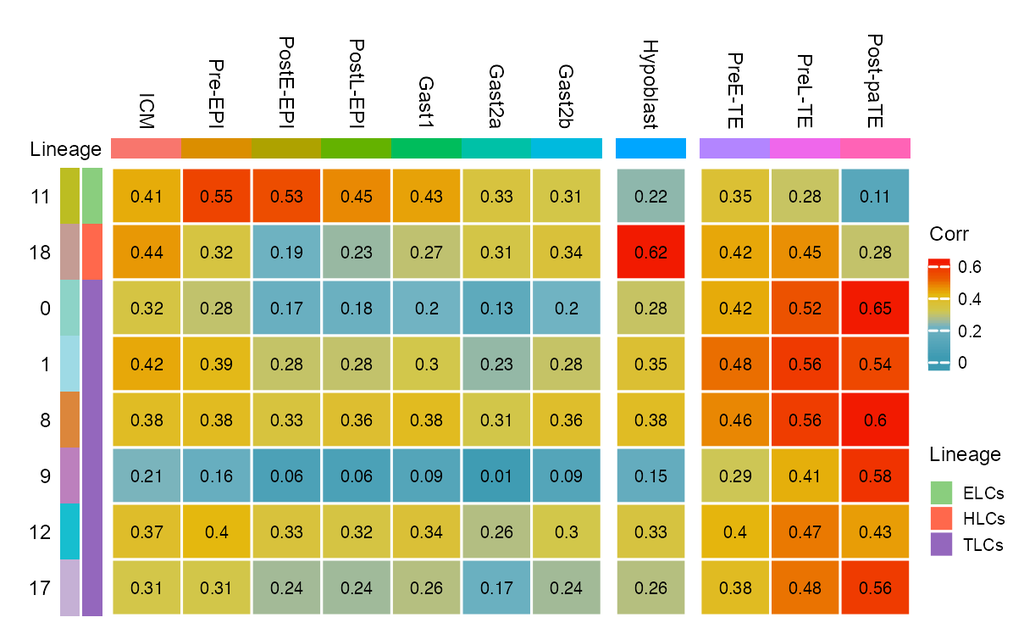

```r
ComplexHeatmap::draw(
    ht,
    heatmap_legend_list = list(pd)
)
```

# Derived stem cells

## Data loading

```r
matrix_readcount_5iLA <- read_delim(
    file = file.path(
        PROJECT_DIR,
        "raw/naive_human_PSC",
        "matrix",
        "xaa_Aligned.sortedByCoord.out_deduped_q10_gene_id_featureCounts.txt.gz"
    ),
    delim = "\t",
    col_names = TRUE,
    skip = 1
) %>%
    dplyr::select(-c(2:6))

matrix_readcount_5iLA <- Matrix(
    data = as.matrix(matrix_readcount_5iLA[, -1]),
    dimnames = list(
        matrix_readcount_5iLA[, 1, drop = TRUE],
        c("5iLA-1", "5iLA-2")
    ),
    sparse = TRUE
)
```

```r
matrix_corr <- cbind(
    matrix_readcount_stem_meta[, c("LW49", "LW50", "LW51", "LW52")],
    "5iLA" = Matrix::rowSums(matrix_readcount_5iLA),
    matrix_readcount_PRJEB7132_meta,
    matrix_readcount_PRJNA576801_meta_lineage,
    matrix_readcount_PRJNA638350_meta_lineage[
        ,
        !colnames(matrix_readcount_PRJNA638350_meta_lineage) %in% c("FT190", "Hec116")
    ],
    matrix_readcount_PRJNA574150_meta_lineage[, "nEnd", drop = FALSE]
)

colnames(matrix_corr) <- c(
    "Naïve_ESCs",
    "Blastoid-nESCs",
    "Blastoid-nEND",
    "Blastoid-hTSCs",
    #
    "5iLA",
    #
    "PRJEB7132:H9",
    "PRJEB7132:H9_reset",
    #
    "PRJNA576801:Naïve_hPSC",
    "PRJNA576801:Naïve_hTSC",
    "PRJNA576801:Primed_hPSC",
    #
    "PRJNA638350:Naïve_hESCs",
    "PRJNA638350:Primed_hESC",
    "PRJNA638350:tdhTSC",
    "PRJNA638350:hTSC",
    #
    "PRJNA574150:nEND"
)

# reorder
matrix_corr <- matrix_corr[
    ,
    c(
        "Naïve_ESCs",
        "Blastoid-nESCs",
        "Blastoid-nEND",
        "Blastoid-hTSCs",
        #
        "5iLA",
        #
        "PRJEB7132:H9",
        "PRJEB7132:H9_reset",
        #
        "PRJNA576801:Naïve_hPSC",
        "PRJNA576801:Primed_hPSC",
        "PRJNA576801:Naïve_hTSC",
        #
        "PRJNA638350:Naïve_hESCs",
        "PRJNA638350:Primed_hESC",
        "PRJNA638350:tdhTSC",
        "PRJNA638350:hTSC",
        #
        "PRJNA574150:nEND"
    )
]

features_ <- c(
    features_hg_cy_EPI_hg,
    features_hg_cy_HYP_hg,
    features_hg_cy_TE_hg
) %>% unique()
```

```r
matrix_heatmap_corr <- cor(
    log10(calc_cpm(matrix_corr)[features_, ] + 1) %>%
        as.matrix()
)
```

## Correlation heatmap

```r
colors_ <- as.character(
    wesanderson::wes_palette("Zissou1", 10, type = "continuous")
)

col_fun <- circlize::colorRamp2(
    seq(0, 1, 0.2),
    # viridis::plasma(11)
    # wesanderson::wes_palette("Zissou1", 51, type = "continuous")
    #
    colors_[c(1, 3, 5, 7, 9, 10)]
)

ht <- ComplexHeatmap::Heatmap(
    matrix_heatmap_corr,
    # name = "heatmap",
    # col = wesanderson::wes_palette("Zissou1", 50, type = "continuous"),
    col = col_fun,
    border = NA,
    rect_gp = grid::gpar(col = "white", lwd = 1),
    cell_fun = function(j, i, x, y, width, height, fill) {
        grid::grid.text(
            round(matrix_heatmap_corr[i, j], 2),
            x, y,
            gp = grid::gpar(fontsize = 5)
        )
    },
    #
    cluster_rows = FALSE,
    cluster_columns = FALSE,
    #
    # row_labels = str_remove(string = rownames(matrix_heatmap), pattern = "^E.+_"),
    row_names_side = c("left"),
    row_names_gp = grid::gpar(fontfamily = "Arial", fontsize = 6),
    show_row_names = TRUE,
    #
    # column_labels = str_remove(string = colnames(matrix_heatmap_corr), pattern = "^.+:"),
    column_labels = colnames(matrix_heatmap_corr),
    column_names_side = c("top"),
    column_names_gp = grid::gpar(fontfamily = "Arial", fontsize = 6),
    # column_names_rot = -90,
    column_names_rot = -45,
    show_column_names = TRUE,
    #
    show_heatmap_legend = FALSE,
    #
    show_row_dend = FALSE,
    show_column_dend = FALSE,
    #
    # top_annotation = ha_column,
    # left_annotation = ha_left,
    #
    heatmap_legend_param = list(
        title = "Corr",
        title_gp = grid::gpar(
            fontfamily = "Arial",
            fontsize = 6
        ),
        legend_direction = "vertical",
        labels_gp = grid::gpar(
            fontfamily = "Arial",
            fontsize = 5
        ),
        legend_height = unit(15, "mm"),
        legend_width = unit(5, "mm")
    ),
    #
    # column_split = ha_group,
    column_gap = unit(1.5, "mm"),
    column_title_gp = grid::gpar(fontfamily = "Arial", fontsize = 6),
    column_title_rot = -90,
    column_title = NULL
)
```

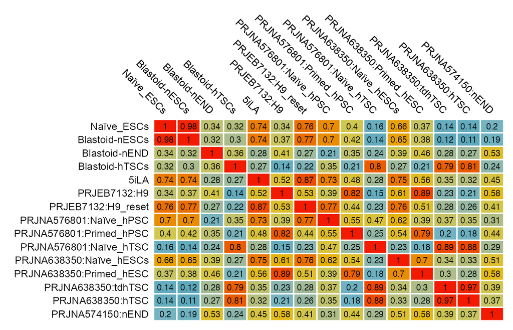

```r
ComplexHeatmap::draw(ht)
```

# R session info

```r
devtools::session_info()$platform
```

```
##  setting  value
##  version  R version 4.0.3 (2020-10-10)
##  os       macOS  11.2
##  system   x86_64, darwin20.2.0
##  ui       unknown
##  language (EN)
##  collate  en_US.UTF-8
##  ctype    en_US.UTF-8
##  tz       America/Chicago
##  date     2021-02-03
```

```r
devtools::session_info()$pack %>%
    as_tibble() %>%
    dplyr::select(
        package,
        loadedversion,
        date,
        `source`
    ) %>%
    # print(n = nrow(Inf))
    gt::gt() %>%
    gt::tab_options(table.font.size = "median")
```